# ECE 401, Signal Processing

# Lecture 1: Introduction to Signal Processing using Python

This Jupyter notebook was released into the public domain by its author, Mark Hasegawa-Johnson. Please feel free to re-use or recycle any part of it at will.

## 0. Outline of the Course

Here's the official course description:

```
Introduction to signal processing for advanced undergraduates or graduate students in the biological, physical, social, engineering and computer sciences. Representation and processing of continuous-time and discrete-time signals and images using phasors, Fourier series, sampling, FIR filters, discrete-time Fourier transform, Z transform, and IIR filters. Machine problems include processing of music, speech, photographic image, bioelectric, and biomedical image data. Course Information: 4 undergraduate hours. 4 graduate hours. Credit is not given towards graduation for both ECE 310 and ECE 401. Prerequisite: MATH 220.
```

If you're an ECE student, please note the second-to-last sentence.

Here are some other links to help you get started:

- The web page for this course is https://courses.engr.illinois.edu/ece401. There, you can find a list of lectures, and information about grading, assignments, and exams.
- The textbook is [Signal Processing First](https://www.mathworks.com/academia/books/signal-processing-first-mccellan.html%3E) by McClellan, Schafer and Yoder.
- All machine problems in this course will use [python](https://docs.python.org/3/tutorial/appetite.html). Instructions for each machine problem, and some lectures (like this one), will use [Jupyter notebooks](https://jupyter.org/). If you don't have a lot of previous python experience, I strongly recommend that you install [Anaconda](https://www.anaconda.com/), because it includes pre-installed versions of many of the packages we will use in this course, including Jupyter, [numpy](https://numpy.org), [pyplot](https://matplotlib.org/stable/tutorials/pyplot.html) and [IPython](https://ipython.org/ipython-doc/dev/api/generated/IPython.display.html).
- If you want to run all of the code in this lecture, you'll also need to install [librosa](https://librosa.org/doc/latest/index.html). You can do that by running the following code block, which uses the exclamation point (!) to run a system command that installs librosa:

```python
!pip install librosa
```

Great! Now let's try creating some signals. Roughly speaking, there are three fundamental types of signals, from which all other signals are constructed: buzz, click, and hiss.

1. A [periodic](https://en.wikipedia.org/wiki/Periodic_function) audio signal might sound like a *buzz*, or if it's more pleasant, a [tone](https://en.wikipedia.org/wiki/Tone). A periodic image signal is called stripes. [Electrocardiogram](https://en.wikipedia.org/wiki/Electrocardiography) signals and weather patterns are approximately periodic.
2. A short-duration audio signal is called an [impulse](https://en.wikipedia.org/wiki/Dirac_delta_function), and sounds like a *click*. A short-duration image signal is called a *dot* or point.
3. An unpredictably random audio, electric, or image signal is called a [stochastic process](https://en.wikipedia.org/wiki/Stochastic_process) and sounds like [noise](https://en.wikipedia.org/wiki/Noise).

## 1. Periodic Signals (Tones)

First, let's create a pure tone, at the frequency of middle C on the piano.

```python
import numpy as np
sr = 8000 # sampling rate, [samples/second]
t = np.arange(sr)/sr # labels for the time axis, in units of seconds
middle_C = 255 # middle C on the piano is about 255 Hz
tone = np.sin(2*np.pi*middle_C*t)  # a tone at middle C
```

Let's view the waveform.

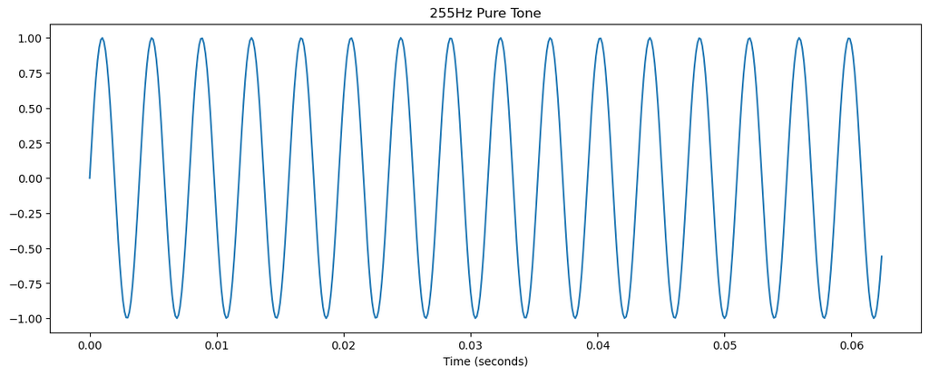

```python
%matplotlib inline
import matplotlib.pyplot as plt
plt.figure(figsize=(14, 5))
plt.plot(t[:500],tone[:500])
plt.xlabel('Time (seconds)')
plt.title('255Hz Pure Tone')
```

Let's view the spectrogram, using librosa.

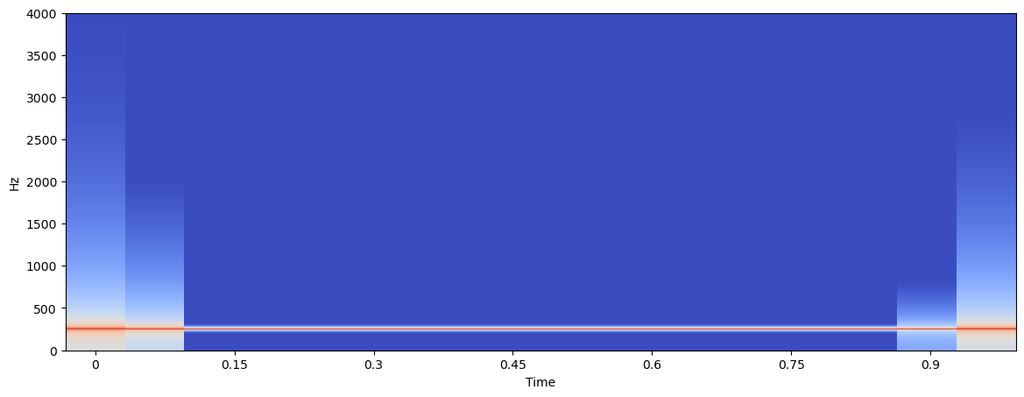

```python
import librosa, librosa.display
TONE = librosa.stft(tone)
TONEdb = librosa.amplitude_to_db(abs(TONE))
plt.figure(figsize=(14, 5))
librosa.display.specshow(TONEdb, sr=sr, x_axis='time', y_axis='hz')
```

Now let's play the tone, using Ipython.display.audio.

```python
import IPython.display as ipd
ipd.Audio(tone, rate=sr)
```

[interactive chart not shown]

Now I want to write the waveform to a file, so I can open it using Praat or any other interface. For this I use soundfile: https://pysoundfile.readthedocs.io/en/latest/. First, we install soundfile in case you don't already have it:

```python
!pip install soundfile
```

... then, use soundfile to save the waveform as an wav file.

```python
import soundfile as sf
sf.write('tone_255.wav', tone, sr)
```

## 2. Impulses (Clicks)

Next, let me create a click. A click is mostly zeros, with just one high-amplitude sample in the middle.

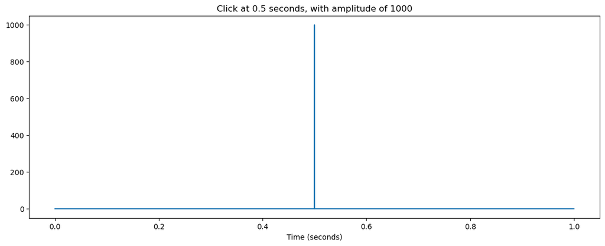

```python
click = np.zeros(8000)
click[4000] = 1000 # arbitrary high-amplitude sample
plt.figure(figsize=(14, 5))
plt.plot(t,click)
plt.xlabel('Time (seconds)')
plt.title('Click at 0.5 seconds, with amplitude of 1000')
```

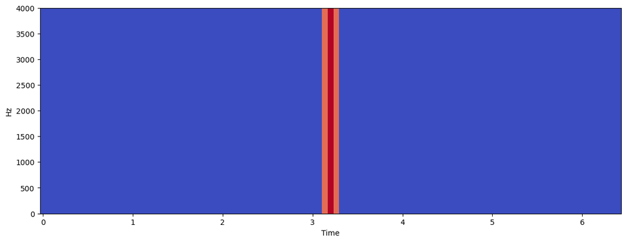

```python
CLICK = librosa.stft(click, hop_length=80, win_length=240)  # 30ms window length, with a 10ms hop between windows
CLICKdb = librosa.amplitude_to_db(abs(CLICK))
plt.figure(figsize=(14, 5))
librosa.display.specshow(CLICKdb, sr=sr, x_axis='time', y_axis='hz')
```

```python
ipd.Audio(click, rate=sr)
```

[interactive chart not shown]

```python
sf.write('click.wav', click, sr)
```

## 3. Stochastic Processes (Noise)

Finally, the third main type of signal: noise. We'll use the function np.random.randn, which generates 8000 independent samples of a zero-mean, unit-variance [Gaussian random variable](https://en.wikipedia.org/wiki/Normal_distribution).

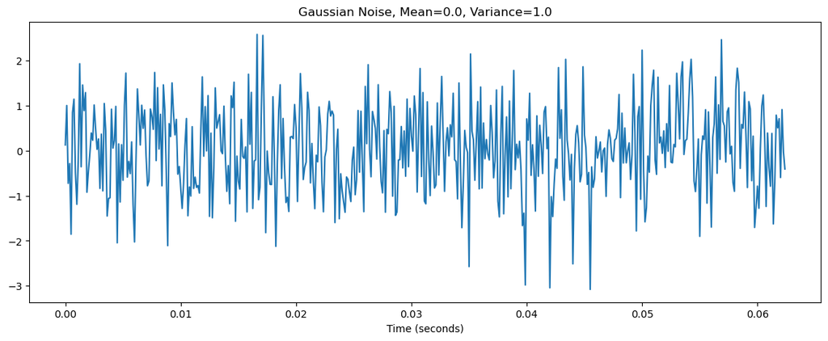

```python
noise = np.random.randn(8000)
plt.figure(figsize=(14, 5))
plt.plot(t[:500],noise[:500])
plt.xlabel('Time (seconds)')
plt.title('Gaussian Noise, Mean=0.0, Variance=1.0')
```

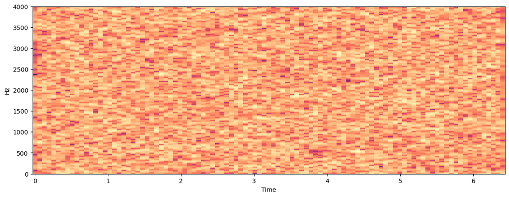

```python
plt.figure(figsize=(14, 5))
NOISE = librosa.stft(noise, hop_length=80, win_length=240)
librosa.display.specshow(librosa.amplitude_to_db(abs(NOISE)), sr=sr, x_axis='time', y_axis='hz')
```

```python
ipd.Audio(noise, rate=sr)
```

[interactive chart not shown]

```python
sf.write('noise.wav', noise, sr)
```

## 4. Quiz

Go to [the course webpage](https://courses.engr.illinois.edu/ece401), click on "Lectures", then click on today's date. That link will take you to the [Prairielearn](https://us.prairielearn.com/) page for this course, to today's quiz.

In every lecture this semester, there will be a short quiz for you to try. Each quiz can be taken as many times as you like; only your highest score will count. You will be permitted to try the quiz any time during the lecture, or any time during the 23 hours following the end of lecture, without penalty; if you submit the quiz more than 23 hours after the end of lecture, you will suffer a small penalty of 5 percent.

## 5. Next Steps

That's all for today!

If you want to learn more about signal processing, you might find it useful to try some of the available audio and video editing tools, for example:

- Interactive tools that combine audio clips into a larger artistic work include IMovie and Garage Band
- Open-source command-line tools for converting between different audio file formats or sampling rates include sox and ffmpeg
- Open-source audio editing tools include Audacity
- Open-source audio annotation tools include ELAN and Praat.

See you next time!